```python
# !pip install numpy
# !pip install matplotlib
```

```python
import numpy as np
import matplotlib.pyplot as plt
```

# Statystyka

### średnia

```python
a = [1, 2, 20, 25, 15]
sum(a)/len(a)
```

```
12.6
```

```python
A = np.array(a)
A.mean()
```

```
12.6
```

```python
M = np.random.randint(0, 10, size=(5, 5))
M
```

```
array([[1, 2, 1, 3, 2],
       [0, 8, 9, 0, 2],
       [6, 8, 4, 0, 9],
       [9, 0, 8, 4, 1],
       [3, 5, 7, 7, 4]])
```

```python
M.mean()
```

```
4.12
```

```python
M.mean(axis=1)  # wierszach
```

```
array([1.8, 3.8, 5.4, 4.4, 5.2])
```

```python
M.mean(axis=0)  # kolumny
```

```
array([3.8, 4.6, 5.8, 2.8, 3.6])
```

### mediana

```python
A = np.array([x for x in range(100) if x%7==0])
A
```

```
array([ 0,  7, 14, 21, 28, 35, 42, 49, 56, 63, 70, 77, 84, 91, 98])
```

```python
np.median(A)
```

```
49.0
```

```python
A = np.random.randint(0, 10, size=20)
A
```

```
array([7, 2, 7, 8, 4, 0, 3, 4, 9, 2, 9, 6, 7, 6, 6, 3, 6, 5, 7, 9])
```

```python
np.median(A)
```

```
6.0
```

```python
print(f"Macierz\n{M}")
print(f"Mediana: {np.median(M)}")
print(f"Mediana dla wierszy: {np.median(M, axis=1)}")
print(f"Mediana dla kolumn: {np.median(M, axis=0)}")
```

```
Macierz
[[1 2 1 3 2]
 [0 8 9 0 2]
 [6 8 4 0 9]
 [9 0 8 4 1]
 [3 5 7 7 4]]
Mediana: 4.0
Mediana dla wierszy: [2. 2. 6. 4. 5.]
Mediana dla kolumn: [3. 5. 7. 3. 2.]
```

### Wariancja

W statystyce wariancję definiuje się jako miarę zmienności, która reprezentuje dystans członków grupy. Gdy wariancja zbioru danych jest mała, pokazuje bliskość punktów danych do średniej, podczas gdy większa wartość wariancji oznacza, że obserwacje są bardzo rozproszone wokół średniej arytmetycznej i od siebie nawzajem.

```python
M
```

```
array([[1, 2, 1, 3, 2],
       [0, 8, 9, 0, 2],
       [6, 8, 4, 0, 9],
       [9, 0, 8, 4, 1],
       [3, 5, 7, 7, 4]])
```

```python
M.var()
```

```
10.025599999999999
```

```python
M.var(axis=1)
```

```
array([ 0.56, 15.36, 10.24, 13.04,  2.56])
```

```python
M.var(axis=0)
```

```
array([10.96, 10.24,  8.56,  6.96,  8.24])
```

### odchylenie standardowe

Odchylenie standardowe jest miarą, która określa ilościowo dyspersję obserwacji w zbiorze danych. Niskie odchylenie standardowe jest wskaźnikiem bliskości wyników do średniej arytmetycznej, wysokie odchylenie standardowe - wyniki są rozproszone w większym zakresie wartości.

```python
M
```

```
array([[1, 2, 1, 3, 2],
       [0, 8, 9, 0, 2],
       [6, 8, 4, 0, 9],
       [9, 0, 8, 4, 1],
       [3, 5, 7, 7, 4]])
```

```python
M.std()
```

```
3.166322788346128
```

```python
M.std() ** 2 == M.var()
M.std() == np.sqrt(M.var())
```

```
True
```

```python
M.std(axis=1)
```

```
array([0.74833148, 3.91918359, 3.2       , 3.61109402, 1.6       ])
```

```python
M.std(axis=0)
```

```
array([3.31058907, 3.2       , 2.92574777, 2.63818119, 2.87054002])
```

### Przykład

###### Zmiana odchylenie standardowego na rozkład normalny

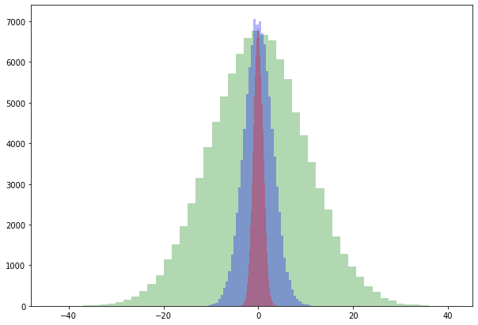

```python
N1 = np.random.normal(loc=0, scale= 1.0, size=100_000)
N2 = np.random.normal(loc=0, scale= 3.0, size=100_000)
N3 = np.random.normal(loc=0, scale=10.0, size=100_000)

plt.figure(figsize=(10, 7))
plt.hist(N3, bins=50, alpha=0.3, color='green')
plt.hist(N2, bins=50, alpha=0.3, color='blue')
plt.hist(N1, bins=50, alpha=0.3, color='red')
plt.show()
```

### Kowariancaja, korelacja

Mówiąc prościej, oba pojęcia mierzą zależność i związek pomiędzy dwoma zmiennymi. “Kowariancja” = kierunek liniowej zależności między zmiennymi. Korelacja”, z drugiej strony, mierzy zarówno siłę, jak i kierunek liniowej zależności między dwiema zmiennymi. Korelacja jest funkcją kowariancji. To, co je wyróżnia, to fakt, że wartości korelacji są standaryzowane, a wartości kowariancji nie. Współczynnik korelacji dwóch zmiennych można uzyskać dzieląc kowariancję tych zmiennych przez iloczyn odchyleń standardowych tych samych wartości. Jeżeli definicja odchylenia standardowego zostanie zrewidowana, to zasadniczo mierzy ona bezwzględną zmienność rozkładu zbioru danych. Dzieląc wartości kowariancji przez odchylenie standardowe, zasadniczo skaluje się wartość w dół do ograniczonego zakresu od -1 do +1. Jest to dokładnie ten zakres wartości korelacji.

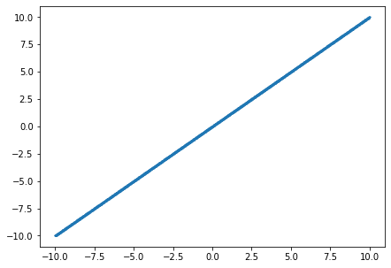

```
Wariancja: 33.07464352696037
Odchylenie standardowe: 5.751055861923128
Koralacja:
[[1. 1.]
 [1. 1.]]
Kowariancja:
[[33.07795132 33.07795132]
 [33.07795132 33.07795132]]
```

```python
# Wartości bez szumu
X = np.random.uniform(-10, 10, 10_000)
noise = np.random.randn(X.size)
y = X  + noise * 0

# X = np.sin(X)
# y = np.cos(y)

plt.figure(figsize=(7, 5))
plt.scatter(X, y, alpha=0.7, s=0.9)
plt.show()

print(f"Wariancja: {y.var()}")
print(f"Odchylenie standardowe: {y.std()}")
print(f"Koralacja:\n{np.corrcoef(X, y)}")  # [-1; 1]
print(f"Kowariancja:\n{np.cov(X, y)}")  # [0; +inf)
```

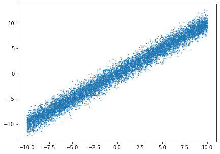

```
Wariancja: 34.901112333445056
Odchylenie standardowe: 5.907716338268541
Koralacja:
[[1.         0.98571951]
 [0.98571951 1.        ]]
Kowariancja:
[[33.97075789 33.94277303]
 [33.94277303 34.90460279]]
```

```python
# Mały szum
X = np.random.uniform(-10, 10, 10_000)
noise = np.random.randn(X.size)
y = X  + noise

# X = np.sin(X)
# y = np.cos(y)

plt.figure(figsize=(7, 5))
plt.scatter(X, y, alpha=0.7, s=0.9)
plt.show()

print(f"Wariancja: {y.var()}")
print(f"Odchylenie standardowe: {y.std()}")
print(f"Koralacja:\n{np.corrcoef(X, y)}")  # [-1; 1]
print(f"Kowariancja:\n{np.cov(X, y)}")  # [0; +inf)
```

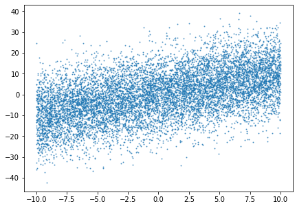

```
Wariancja: 131.6316477780506
Odchylenie standardowe: 11.473083621156546
Koralacja:
[[1.         0.50076472]
 [0.50076472 1.        ]]
Kowariancja:
[[ 33.53968362  33.27477104]
 [ 33.27477104 131.64481226]]
```

```python
# Duży szum
X = np.random.uniform(-10, 10, 10_000)
noise = np.random.randn(X.size)
y = X  + noise * 10

# X = np.sin(X)
# y = np.cos(y)

plt.figure(figsize=(7, 5))
plt.scatter(X, y, alpha=0.7, s=0.9)
plt.show()

print(f"Wariancja: {y.var()}")
print(f"Odchylenie standardowe: {y.std()}")
print(f"Koralacja:\n{np.corrcoef(X, y)}")  # [-1; 1]
print(f"Kowariancja:\n{np.cov(X, y)}")  # [0; +inf)
```

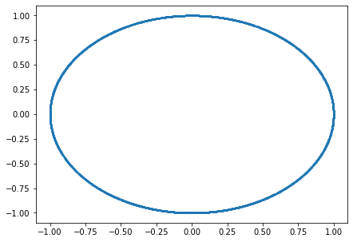

```
Wariancja: 0.525419734096804
Odchylenie standardowe: 0.7248584234847547
Koralacja:
[[ 1.        -0.0011736]
 [-0.0011736  1.       ]]
Kowariancja:
[[ 0.47208859 -0.00058453]
 [-0.00058453  0.52547228]]
```

```python
# Zależność nieliniowa
X = np.random.uniform(-10, 10, 10_000)
y = X

X = np.sin(X)
y = np.cos(y)

plt.figure(figsize=(7, 5))
plt.scatter(X, y, alpha=0.7, s=0.9)
plt.show()

print(f"Wariancja: {y.var()}")
print(f"Odchylenie standardowe: {y.std()}")
print(f"Koralacja:\n{np.corrcoef(X, y)}")  # [-1; 1]
print(f"Kowariancja:\n{np.cov(X, y)}")  # [0; +inf)
```

```python
%%bash
jupyter nbconvert \
    --to html Statystyka.ipynb \
    --output-dir ./HTML
```